# Genetics of common complex psychiatric disorders II

Mark James Adams

# Part 2: Molecular genetics

Mark James Adams  
Division of Psychiatry  
`mark.adams@ed.ac.uk`  
*Genetics and Environmental Influences on Behaviour and Mental Health*

## Structure of DNA

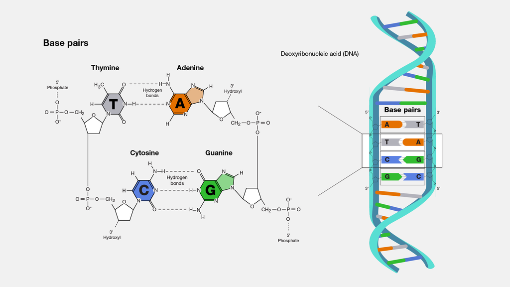

## Gene structure

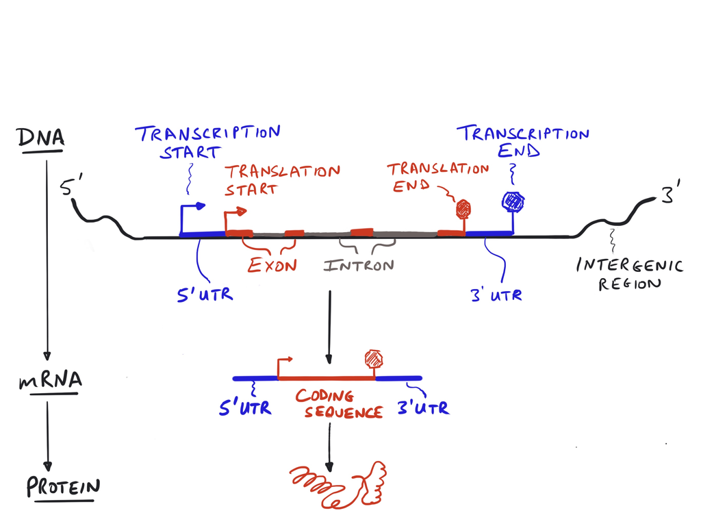

## Types and sizes of genetic variants

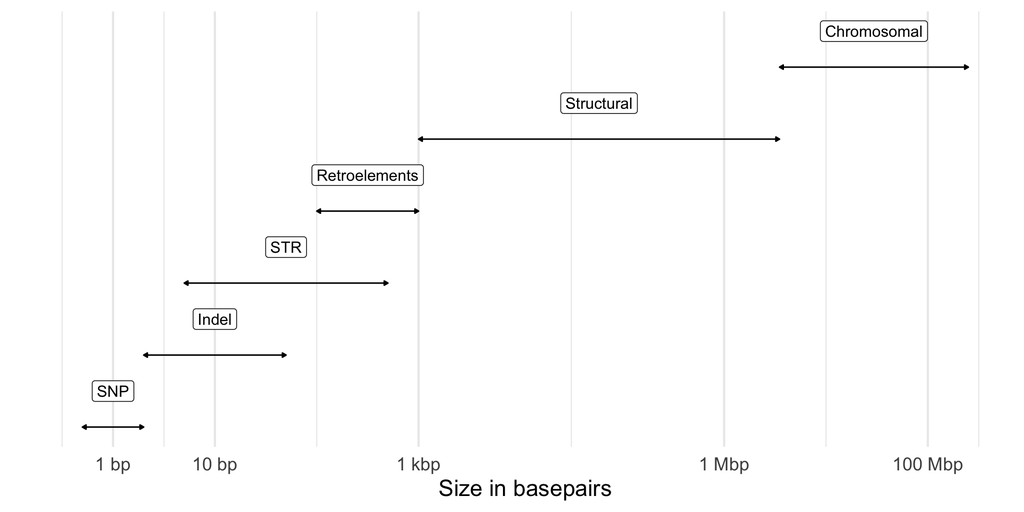

## Chromosomes

Diploid (two copies of each chromosome)

[figure not shown]

## Single Nucleotide Polymorphisms (SNP)

[figure not shown]

- Single base of DNA is substituted with another.
- Occur in 1 of every 100 - 1000 basepairs (bp).
- Currently, ± 1.2B SNPs are known.
- Labelled with a dbSNP Reference ID (“rs number”)

## Candidate gene studies (circa 2000)

Example: Catechol-O-methyltransferase (COMT)

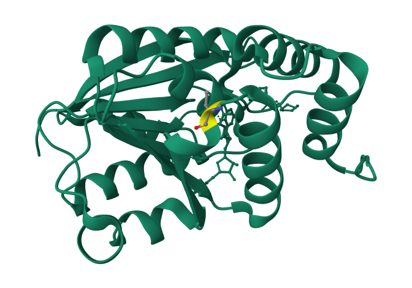

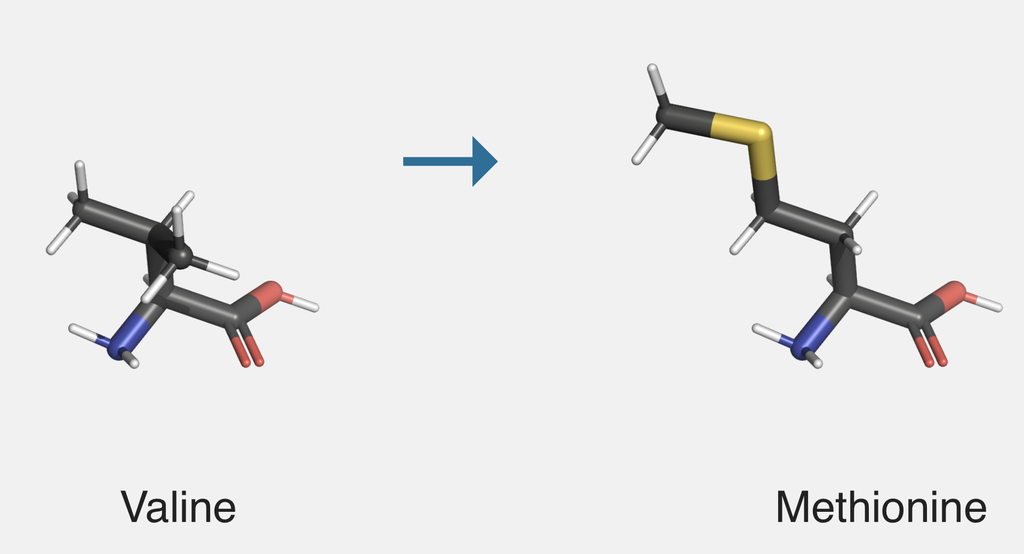

SNP rs4680 G>A substitution (missense variant) results in amino acid change from valine to methionine at codon 158 (Val158Met).

# GWAS

## Genome-wide associations studies (GWAS) (2007 - today)

- Candidate gene findings did not replicate
- Power analysis: candidate gene study sample sizes were *vastly* too small
- Alternative: Assay the whole genome (hundreds of thousands or millions of variants)
- Hypothesis-free testing

## Conducting a GWAS

- Two alleles: A and a
- Three genotypes: AA, Aa, aa
- Arbitrarily select one allele (A) as the *effect* allele
- For each subject, count number of effect alleles: $x = 0, 1, 2$

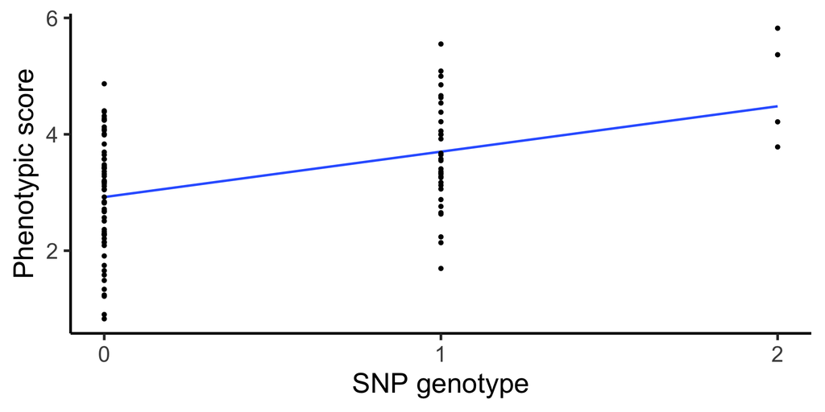

## 15+ years of GWAS

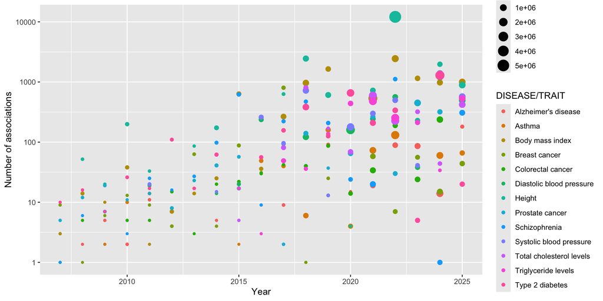

## GWAS data

| CHROM | POS | ID | REF | ALT | P | OR | AF |
| --- | --- | --- | --- | --- | --- | --- | --- |
| chr1 | 1006415 | rs145588482 | TGGCAGCTC | T | 0.0004688 | 0.583384 | 0.01293 |
| chr1 | 1007256 | rs76233940 | G | A | 0.0004016 | 0.579783 | 0.01301 |
| chr1 | 1341559 | rs376494450 | C | T | 0.0001512 | 1.320130 | 0.02706 |
| chr1 | 1480224 | rs71628972 | A | G | 0.0007602 | 1.412750 | 0.01319 |
| chr1 | 2035619 | rs111334586 | C | T | 0.0009206 | 1.413370 | 0.01209 |
| chr1 | 2213349 | rs262695 | A | G | 0.0008815 | 0.904873 | 0.32073 |

## Plotting GWAS results

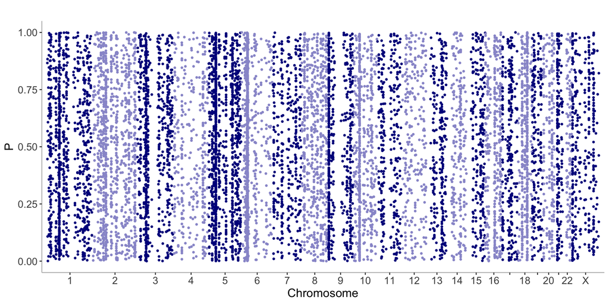

## Plotting GWAS results

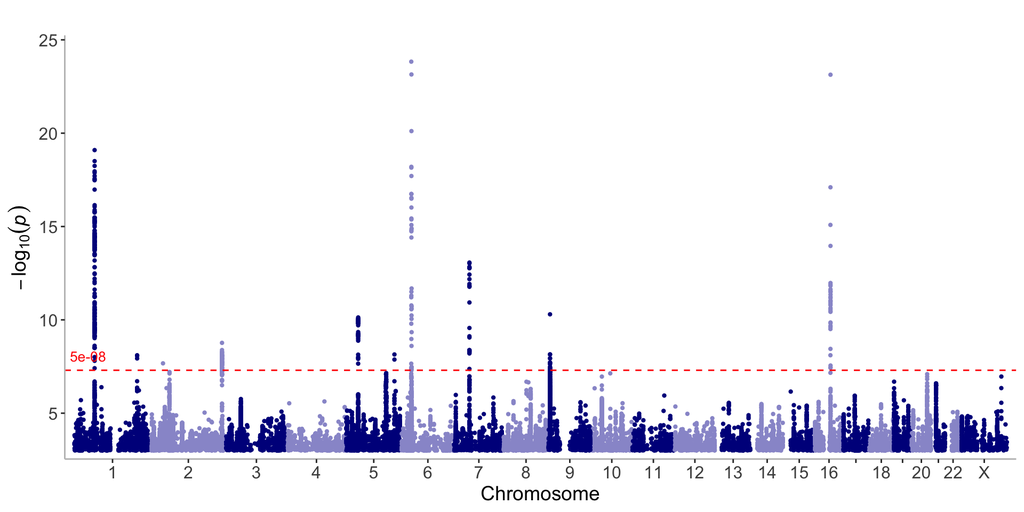

## Region plots

```
[1] "Zoomed to region:  1:67038907-67359979"
```

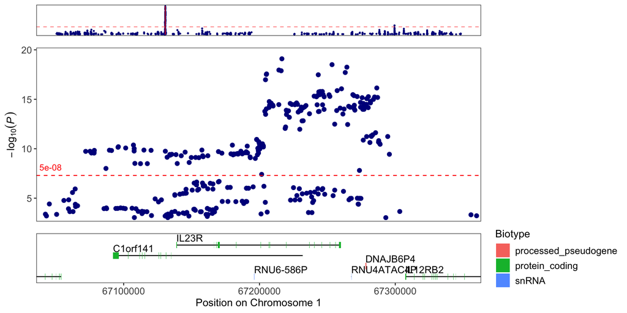

## Linkage disequilibrium

```
[1] "Zoomed to region:  1:67042284-67359988"
```

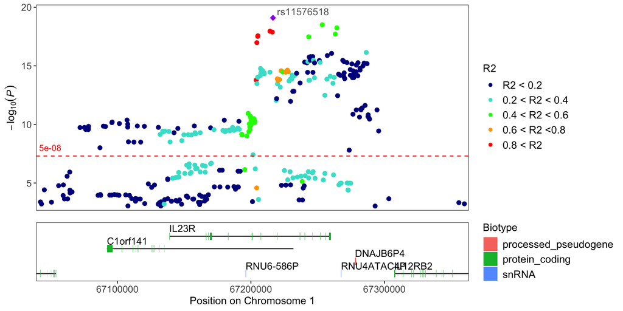

## Key findings from psychiatric GWAS

| Disorder | Key findings |
| --- | --- |
| Alcohol dependence | Genetically distinct from alcohol consumption but alcohol metabolism is key |
| Attention deficit/hyperactivity disorder | Common variants do not explain sex bias |
| Bipolar disorder | Calcium channel genes; neuronal hyperexcitability; Bipolar I ⇌ Schizophrenia; Bipolar II ⇌ Major depressive disorder |
| Major depression | Synaptic structure, neurotransmission; Prefrontal brain regions; Both ancestry and geography matter |
| Post-traumatic stress disorder | Higher heritability in women |
| Schizophrenia | Glutamatergic neurotransmission; Immunity; Disruptive coding variants |

## Crossing diagnostic boundaries

Genetic correlation between phenotypes based on GWAS data

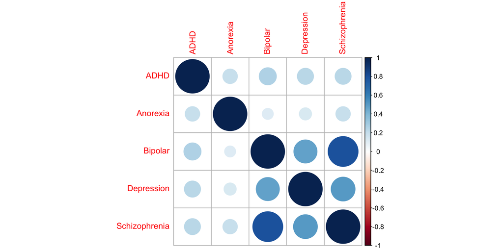

# Prediction

## GWAS is a model

$$Y \sim a + b_i \times \mathrm{SNP}_i + e$$

## What if we reverse that?

$$\hat{Y} = \hat{a} + \hat{b} \times \mathrm{SNP}$$

## Polygenic score

$$\hat{Y} = \sum_i^n \hat{b}_i \times \mathrm{SNP}_i$$

## Calculating polygenic scores

| SNP | Effect allele | Non-effect allele | Beta | $P$ |
| --- | --- | --- | --- | --- |
| rs61902807 | C | T | -0.0352 | $1.45 \times 10^{-44}$ |
| rs12142986 | T | C | 0.0318 | $3.38 \times 10^{-41}$ |
| rs4702 | G | A | 0.0276 | $1.15 \times 10^{-30}$ |

At SNP rs61902807, the genotype contributions to the score would be

- TT: 0
- CT or TC: -0.0352
- CC: -0.0704

## Polygenic prediction of major depression

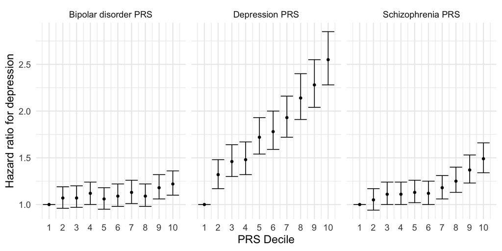

## Research and clinical utility

> “The accuracy with which a polygenic score can predict psychiatric illnesses, such as schizophrenia, bipolar disorder and major depression, is currently not sufficient for clinical use.”

International Society of Psychiatric Genetics, *[Advisory on the Use of Polygenic Risk Scores to Screen Embryos for Adult Mental Conditions.](https://ispg.net/ethics-statement/)*

# Causal analysis

## Causality from genetics: Mendelian Randomisation

Mendel’s Second Law of Independent Assortment is analogous to a randomised control trial, dubbed “Mendelian randomisation (MR).

- Uses: Overcome confounding, reverse causation, selection bias, measurement attenuation
- Limitations: Reliable gene–phenotype link, pleiotropy, linkage disequilibrium

## Genetic variant as an instrumental variable

[figure not shown]

## Genetic instrument from GWAS on exposure and outcome

[figure not shown]

## Estimating effect of exposure on outcome

[figure not shown]

### Mendelian randomisation study: modifiable risk factors and depression

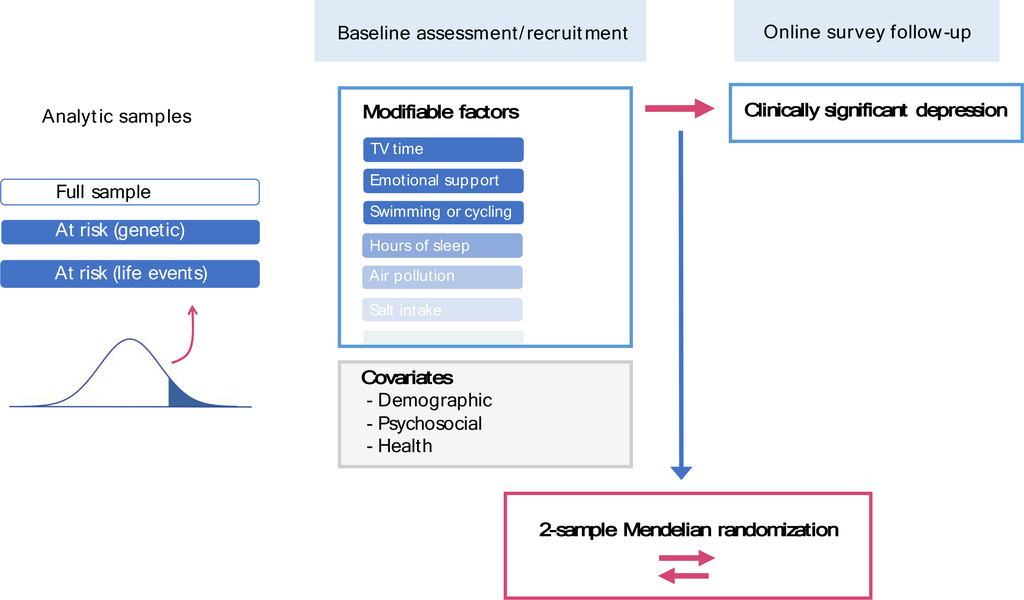

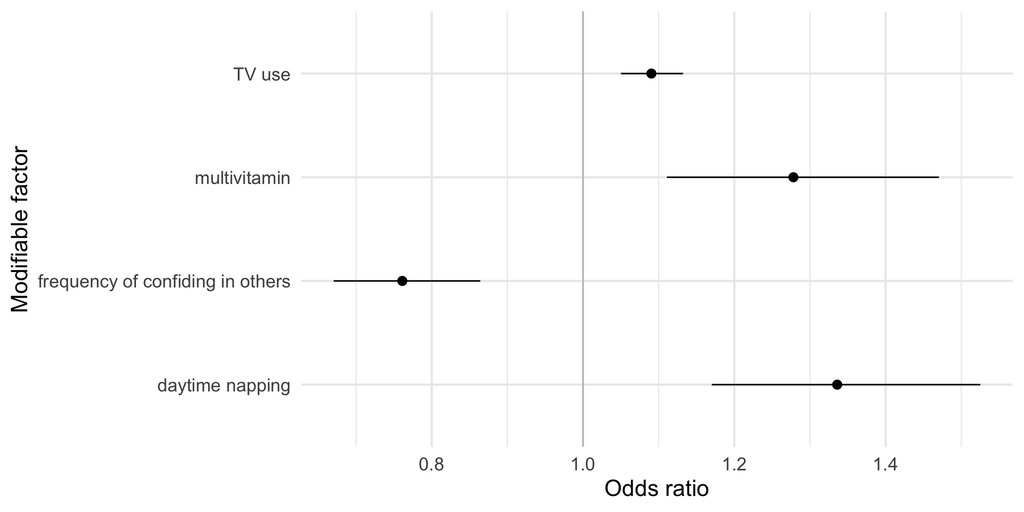